# PIGAL - Analyse PLS multiblocs suivie d’une classification k-means des variables respiratoires

Christelle FABLET

2025-03-09

**Packages**

```r
# chargement des packages nécessaires pour la suite
library(fastDummies)
library(ade4)
library(factoextra)
library(cluster)
library(knitr)
library(table1)
library(FactoMineR)
library(dplyr)
library(writexl)
```

**Charger les données**

## _______________________________________________________________________________

#Analyse multiblocs - 21 variables X et une variable Y

## _______________________________________________________________________________

data.clean = fichier contenant 21 variables X et une variable Y.

*Etape 1*

On réalise le découpage par les blocs en accord avec le fichier variables_Sujet_22_envoi.xlsx

```r
X01_Logement_Entretien <- data.clean[, c("X22x1_LOC_INF_rec", "X07x1_AN_CONST4_mean_3", "ENG_TROU", "T13_ENG_milieuDegrad.x")]
X02_Alimentation <- data.clean[, c("T10_PS_EauDebi_3", "T10_PS_AlimPoNourrLongpPo", "X09x3_FAB_CROISS_reg_rec")]
X03_Gestion_Maladies <- data.clean[, c("X18x2_ABBTX_PS", "X19x2_ABB_E")]
X04_Biosecurite <- data.clean[, c("X12x2_MAT_PC", "X12x2_MAT1FRLAV_1", "T16_BS_TenueSpeciElev", "X13x2_QUAI_t")]
X05_Facteurs_Infectieux <- data.clean[, c("A03_Pos10sVERS", "A03_PosSeroMyAs", "A03_TxPosSero22sTgReel", "A04_My10Mfloc", "A05_TxPos10sGRIPPEReel")]
X06_Caracteristiques_Generales <- data.clean[, c("X06x1_gene_majo_1_rec", "X25x1_ElvAlterChoiPers", "LR_LRF")]
```

*Etape 2*

Création des dummy (ie binaires) variables avec le package fastDummies. La variable prise en référence correspond à celle dont l’effectif de réponse est le plus élevé.

```r
data <- list(X01_Logement_Entretien, X02_Alimentation, X03_Gestion_Maladies, X04_Biosecurite, X05_Facteurs_Infectieux, X06_Caracteristiques_Generales)

for(i in 1:length(data)){
  df <- data[[i]]
  for(var in names(df)){
    if(is.factor(df[[var]])){
      df <- dummy_cols(df, var, remove_selected_columns = TRUE, remove_most_frequent_dummy = TRUE)
    }
  }
  data[[i]] <- df
}
```

*Etape 3* La variable Y est en 3 modalités donc elle est également recodée en dummy variables selon le code indiqué ci-dessous. Introduction de la variable Y codée en 3 dummy (ie transformation de Y en 3 variables binaires) variables :

```r
dummy_y <- data.frame(y = data.clean$y)

# Create des 3 Y
dummy_y$sain <- as.integer(dummy_y$y == "Sain")
dummy_y$ps_malade <- as.integer(dummy_y$y == "PS_malade")
dummy_y$eng_malade <- as.integer(dummy_y$y == "ENG_malade")

#suppression de y, la variable Y initiale, qui a été récodée en 3 niveaux Y
dummy_y <- dummy_y[,-1]
summary(dummy_y)
```

```
##       sain        ps_malade      eng_malade
##  Min.   :0.00   Min.   :0.00   Min.   :0.0
##  1st Qu.:0.00   1st Qu.:0.00   1st Qu.:0.0
##  Median :0.00   Median :0.00   Median :0.0
##  Mean   :0.29   Mean   :0.31   Mean   :0.4
##  3rd Qu.:1.00   3rd Qu.:1.00   3rd Qu.:1.0
##  Max.   :1.00   Max.   :1.00   Max.   :1.0
```

```r
# Vérifions que la moyenne vaut bien 1
sum(unlist(lapply(dummy_y, mean))) == 1
```

```
## [1] TRUE
```

*Etape 4* Création d’un bloc pour la variable Y codée en dummy variables.

```r
# on ne prendra pas le plus fréquent ie eng_malade
summary(dummy_y)
```

```
##       sain        ps_malade      eng_malade
##  Min.   :0.00   Min.   :0.00   Min.   :0.0
##  1st Qu.:0.00   1st Qu.:0.00   1st Qu.:0.0
##  Median :0.00   Median :0.00   Median :0.0
##  Mean   :0.29   Mean   :0.31   Mean   :0.4
##  3rd Qu.:1.00   3rd Qu.:1.00   3rd Qu.:1.0
##  Max.   :1.00   Max.   :1.00   Max.   :1.0
```

```r
#création d'un vecteur Y
bloc.Y <- dummy_y[,1:2]

data[[7]] <- bloc.Y
```

*Etape 5*

Renommer les blocs:

```r
new_names <- c("X01_Logement_Entretien", "X02_Alimentation", "X03_Gestion_Maladies", "X04_Biosecurite", "X05_Facteurs_Infectieux", "X06_Caracteristiques_Generales", "Bloc_Y")
names(data) <- new_names
```

*Etape 6*

**PASSAGE à l’analyse mbPLS**

## Préparation des données

```r
Y <- data[[7]]

row.names(Y)<-rownames(data[[1]])
#renommer les lignes du nouveau Y par les numéros des data 1 à 7 car Y prend le code elevage (PIGAL/ELEV/01...) alors que les autres fichiers ont un numéro d'ordre (perte du code_elevage); sans cela le code d'après bloque #à voir si cette étape est nécessaire dans votre code selon la configuration de votre fichier.
dudiY.ergo <- dudi.pca(Y, center = TRUE, scale = TRUE, scannf = FALSE)
ktabX.ergo <- ktab.list.df(data[1:6])
```

## mbPLS

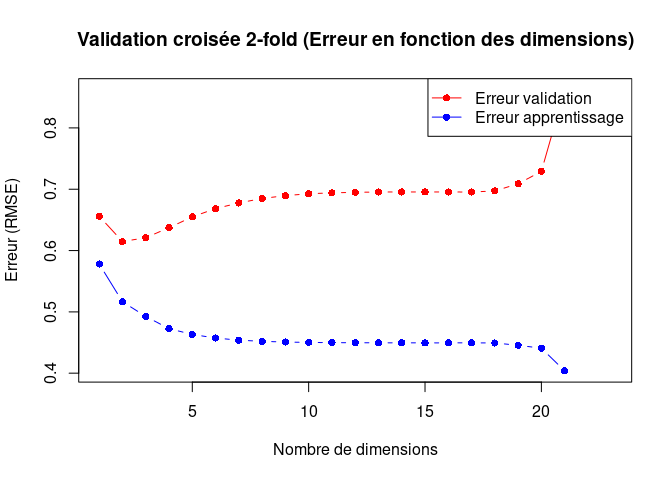

```r
res.mbpls2   <- mbpls(dudiY.ergo, ktabX.ergo, scale = T, option = "uniform", scannf = FALSE, nf = 10)


res.2foldcv2 <- testdim(res.mbpls2, nrepet = 500)  # calcul long


###########

# Remplacer les NaN par NA pour éviter les erreurs
rmsec_values <- res.2foldcv2$statsRMSEc$Mean
rmsec_values[is.nan(rmsec_values)] <- NA

# Définir les limites de l'axe Y pour inclure les deux courbes
ylim_range <- range(c(res.2foldcv2$statsRMSEv$Mean, rmsec_values), na.rm = TRUE)

# Tracer la courbe d'erreur de validation (rouge)
plot(1:23, res.2foldcv2$statsRMSEv$Mean, type = "b", pch = 16, col = "red",
     xlab = "Nombre de dimensions", ylab = "Erreur (RMSE)", ylim = ylim_range,
     main = "Validation croisée 2-fold (Erreur en fonction des dimensions)")

# Ajouter la courbe d'erreur d'apprentissage (bleue)
lines(1:23, rmsec_values, type = "b", pch = 16, col = "blue")

# Ajouter la légende
legend("topright", legend = c("Erreur validation", "Erreur apprentissage"),
       col = c("red", "blue"), pch = 16, lty = 1)
```

NB : les variables X sont centrées et réduites à ce niveau

# Récupération des composantes de tous les axes pour réaliser une classification k-means à partir de ces composantes

```r
#pour les X
recup_compos_X<-res.mbpls2$lX
#pour les Y
recup_compos_Y<-res.mbpls2$lY
```

```r
selection_dimensions <- function(res.mbpls, n_dim){
  #composantes du bloc X
  data_clust <- res.mbpls[,c(1:n_dim)] #x premières composantes récupérées pour la suite de la classification
  data_clust.scaled <- scale(data_clust) # centrer

  #calculate gap statistic based on number of clusters
  gap_stat <- clusGap(data_clust.scaled,
                      FUN = kmeans,
                      nstart = 25,
                      K.max = 12,
                      B = 150)

  #plot number of clusters vs. gap statistic
  return(fviz_gap_stat(gap_stat))
}

analyse_clusters <- function(res.mbpls, donnees, n_dim, centers){
  data_clust <- res.mbpls[,c(1:n_dim)] #x premières composantes récupérées pour la suite de la classification
  data_clust.scaled <- scale(data_clust) # centrer


  #perform k-means clustering with k = x clusters (x=centers)
  res.km <- kmeans(data_clust.scaled, centers = centers, nstart = 25)


  #plot results of final k-means model
  resultat.2dim <- fviz_cluster(res.km, data = data_clust.scaled,
              geom = "point",
              ellipse.type = "convex",
              ggtheme = theme_bw()
              )

  data.avec_cl <- cbind(donnees, res.km$cluster)
  nom.clust <- paste0("cluster_km", n_dim)
  names(data.avec_cl) <- c(names(donnees), nom.clust)

  data.avec_clb <-data_frame(data.avec_cl)

  #déclarer la variable cluster_km en facteur
  data.avec_clb[[nom.clust]] <- as.factor(data.avec_clb[[nom.clust]])

  data.table <- kable(table1(as.formula(paste("~ . |", nom.clust)), data = data.avec_clb))

  data.dsc <- catdes(data.avec_clb, num.var = ncol(data.avec_clb), proba =0.05)$category



  cluster_list <- list()
  for (i in 1:centers) {
    cluster_list[[paste("cluster", i, sep = "_")]] <- as.data.frame(data.dsc[[as.character(i)]])
    cluster_list[[paste("cluster", i, sep = "_")]] <- dplyr::as_data_frame(cluster_list[[paste("cluster", i, sep = "_")]], rownames = "Variable")
  }
  file_path <- paste0("mb-pls/Clusters_km", paste0(n_dim, ".xlsx"))
  write_xlsx(cluster_list, file_path, col_names = TRUE, format_headers = TRUE, use_zip64 = FALSE)

  return(list("res.km"=res.km,
               "plot.km"=resultat.2dim,
               "res.table"=data.table,
               "res.catdes"=data.dsc))

}

choix_dim_et_res <- function(res.mbpls, donnees, n_dim, centers=NULL){
  sel.dim <- selection_dimensions(res.mbpls, n_dim)

  if (is.null(centers)) {

    centers <- as.integer(readline(prompt = "Please input the number of clusters you want to use: "))

  }

  an.cl <- analyse_clusters(res.mbpls, donnees, n_dim, centers)

  return(list( "plot.opti_cluster"=sel.dim,
               "analyse"=an.cl))

}
```

# Réaliser une classification k-means à partir des deux premières dimensions

```r
res <- choix_dim_et_res(res.mbpls=recup_compos_X,
                        donnees=data.clean,
                        n_dim=2,
                        centers=4)
```

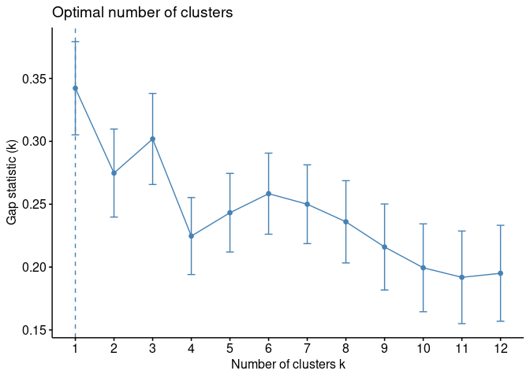

```r
res$plot.opti_cluster
```

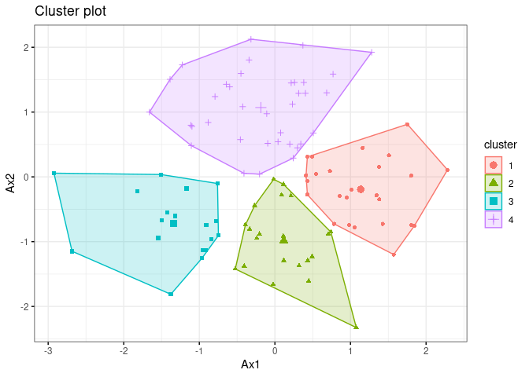

```r
res$analyse$plot.km
```

```r
res$analyse$res.table
```

|  | 1 | 2 | 3 | 4 | Overall |
| --- | --- | --- | --- | --- | --- |
|  | (N=25) | (N=21) | (N=18) | (N=36) | (N=100) |
| X09x3_FAB_CROISS_reg_rec |  |  |  |  |  |
| 0 | 10 (40.0%) | 11 (52.4%) | 15 (83.3%) | 19 (52.8%) | 55 (55.0%) |
| 1 | 15 (60.0%) | 10 (47.6%) | 3 (16.7%) | 17 (47.2%) | 45 (45.0%) |
| X22x1_LOC_INF_rec |  |  |  |  |  |
| 0 | 13 (52.0%) | 12 (57.1%) | 10 (55.6%) | 21 (58.3%) | 56 (56.0%) |
| 1 | 12 (48.0%) | 9 (42.9%) | 8 (44.4%) | 15 (41.7%) | 44 (44.0%) |
| X06x1_gene_majo_1_rec |  |  |  |  |  |
| 0 | 3 (12.0%) | 1 (4.8%) | 3 (16.7%) | 12 (33.3%) | 19 (19.0%) |
| 1 | 22 (88.0%) | 20 (95.2%) | 15 (83.3%) | 24 (66.7%) | 81 (81.0%) |
| X12x2_MAT_PC |  |  |  |  |  |
| 1 | 7 (28.0%) | 9 (42.9%) | 11 (61.1%) | 10 (27.8%) | 37 (37.0%) |
| 2 | 18 (72.0%) | 12 (57.1%) | 7 (38.9%) | 26 (72.2%) | 63 (63.0%) |
| T10_PS_EauDebi_3 |  |  |  |  |  |
| 0 | 11 (44.0%) | 6 (28.6%) | 7 (38.9%) | 18 (50.0%) | 42 (42.0%) |
| 1 | 8 (32.0%) | 14 (66.7%) | 10 (55.6%) | 10 (27.8%) | 42 (42.0%) |
| 2 | 6 (24.0%) | 1 (4.8%) | 1 (5.6%) | 8 (22.2%) | 16 (16.0%) |
| X12x2_MAT1FRLAV_1 |  |  |  |  |  |
| 0 | 5 (20.0%) | 10 (47.6%) | 8 (44.4%) | 2 (5.6%) | 25 (25.0%) |
| 1 | 5 (20.0%) | 7 (33.3%) | 10 (55.6%) | 13 (36.1%) | 35 (35.0%) |
| 2 | 15 (60.0%) | 4 (19.0%) | 0 (0%) | 21 (58.3%) | 40 (40.0%) |
| X07x1_AN_CONST4_mean_3 |  |  |  |  |  |
| 0 | 5 (20.0%) | 10 (47.6%) | 10 (55.6%) | 11 (30.6%) | 36 (36.0%) |
| 1 | 7 (28.0%) | 2 (9.5%) | 2 (11.1%) | 14 (38.9%) | 25 (25.0%) |
| 2 | 13 (52.0%) | 9 (42.9%) | 6 (33.3%) | 11 (30.6%) | 39 (39.0%) |
| T16_BS_TenueSpeciElev |  |  |  |  |  |
| 0 | 7 (28.0%) | 2 (9.5%) | 0 (0%) | 10 (27.8%) | 19 (19.0%) |
| 1 | 18 (72.0%) | 19 (90.5%) | 18 (100%) | 26 (72.2%) | 81 (81.0%) |
| X13x2_QUAI_t |  |  |  |  |  |
| 0 | 17 (68.0%) | 11 (52.4%) | 3 (16.7%) | 21 (58.3%) | 52 (52.0%) |
| 1 | 8 (32.0%) | 10 (47.6%) | 15 (83.3%) | 15 (41.7%) | 48 (48.0%) |
| ENG_TROU |  |  |  |  |  |
| 0 | 22 (88.0%) | 17 (81.0%) | 15 (83.3%) | 17 (47.2%) | 71 (71.0%) |
| 1 | 3 (12.0%) | 4 (19.0%) | 3 (16.7%) | 19 (52.8%) | 29 (29.0%) |
| X25x1_ElvAlterChoiPers |  |  |  |  |  |
| 0 | 16 (64.0%) | 13 (61.9%) | 6 (33.3%) | 12 (33.3%) | 47 (47.0%) |
| 1 | 9 (36.0%) | 8 (38.1%) | 12 (66.7%) | 24 (66.7%) | 53 (53.0%) |
| LR_LRF |  |  |  |  |  |
| 0 | 24 (96.0%) | 18 (85.7%) | 17 (94.4%) | 25 (69.4%) | 84 (84.0%) |
| 1 | 1 (4.0%) | 3 (14.3%) | 1 (5.6%) | 11 (30.6%) | 16 (16.0%) |
| T13_ENG_milieuDegrad.x |  |  |  |  |  |
| 0 | 19 (76.0%) | 13 (61.9%) | 6 (33.3%) | 13 (36.1%) | 51 (51.0%) |
| 1 | 6 (24.0%) | 8 (38.1%) | 12 (66.7%) | 23 (63.9%) | 49 (49.0%) |
| X18x2_ABBTX_PS |  |  |  |  |  |
| 0 | 17 (68.0%) | 21 (100%) | 13 (72.2%) | 5 (13.9%) | 56 (56.0%) |
| 1 | 8 (32.0%) | 0 (0%) | 5 (27.8%) | 31 (86.1%) | 44 (44.0%) |
| X19x2_ABB_E |  |  |  |  |  |
| 0 | 20 (80.0%) | 13 (61.9%) | 6 (33.3%) | 4 (11.1%) | 43 (43.0%) |
| 1 | 5 (20.0%) | 8 (38.1%) | 12 (66.7%) | 32 (88.9%) | 57 (57.0%) |
| A03_Pos10sVERS |  |  |  |  |  |
| 0 | 8 (32.0%) | 16 (76.2%) | 17 (94.4%) | 24 (66.7%) | 65 (65.0%) |
| 1 | 17 (68.0%) | 5 (23.8%) | 1 (5.6%) | 12 (33.3%) | 35 (35.0%) |
| A03_PosSeroMyAs |  |  |  |  |  |
| Non | 9 (36.0%) | 10 (47.6%) | 14 (77.8%) | 18 (50.0%) | 51 (51.0%) |
| Oui | 16 (64.0%) | 11 (52.4%) | 4 (22.2%) | 18 (50.0%) | 49 (49.0%) |
| T10_PS_AlimPoNourrLongpPo |  |  |  |  |  |
| Mean (SD) | 5.35 (3.21) | 7.05 (1.63) | 10.8 (5.52) | 5.69 (1.92) | 6.81 (3.67) |
| Median [Min, Max] | 5.15 [1.19, 12.8] | 7.11 [4.16, 11.5] | 8.44 [6.19, 25.9] | 5.91 [1.88, 9.60] | 6.57 [1.19, 25.9] |
| A03_TxPosSero22sTgReel |  |  |  |  |  |
| Mean (SD) | 8.28 (23.1) | 10.6 (19.4) | 0.891 (3.29) | 5.94 (13.7) | 6.59 (16.8) |
| Median [Min, Max] | 0 [0, 82.4] | 0 [0, 55.0] | 0 [0, 14.1] | 0.396 [0, 55.0] | 0 [0, 82.4] |
| A04_My10Mfloc |  |  |  |  |  |
| Mean (SD) | 17100 (54500) | 35100 (84100) | 112000 (235000) | 12900 (30200) | 36400 (115000) |
| Median [Min, Max] | 0 [0, 271000] | 0 [0, 298000] | 1510 [0, 854000] | 0 [0, 139000] | 0 [0, 854000] |
| A05_TxPos10sGRIPPEReel |  |  |  |  |  |
| Mean (SD) | 24.1 (38.3) | 9.55 (20.3) | 22.6 (37.2) | 39.5 (43.3) | 26.3 (38.3) |
| Median [Min, Max] | 0 [0, 100] | 0 [0, 73.9] | 0 [0, 100] | 21.1 [0, 100] | 0 [0, 100] |
| y |  |  |  |  |  |
| ENG_malade | 4 (16.0%) | 5 (23.8%) | 3 (16.7%) | 28 (77.8%) | 40 (40.0%) |
| PS_malade | 20 (80.0%) | 8 (38.1%) | 1 (5.6%) | 2 (5.6%) | 31 (31.0%) |
| Sain | 1 (4.0%) | 8 (38.1%) | 14 (77.8%) | 6 (16.7%) | 29 (29.0%) |

```r
res$analyse$res.catdes
```

```
## $`1`
##                            Cla/Mod Mod/Cla Global      p.value    v.test
## y=PS_malade              64.516129      80     31 4.248841e-09  5.874202
## X19x2_ABB_E=0            46.511628      80     43 2.027822e-05  4.261805
## A03_Pos10sVERS=1         48.571429      68     35 1.234891e-04  3.839094
## T13_ENG_milieuDegrad.x=0 37.254902      76     51 4.239200e-03  2.859791
## X12x2_MAT1FRLAV_1=2      37.500000      60     40 2.246206e-02  2.282462
## ENG_TROU=0               30.985915      88     71 2.896466e-02  2.183967
## ENG_TROU=1               10.344828      12     29 2.896466e-02 -2.183967
## y=ENG_malade             10.000000      16     40 4.324844e-03 -2.853442
## T13_ENG_milieuDegrad.x=1 12.244898      24     49 4.239200e-03 -2.859791
## y=Sain                    3.448276       4     29 7.159584e-04 -3.383394
## A03_Pos10sVERS=0         12.307692      32     65 1.234891e-04 -3.839094
## X19x2_ABB_E=1             8.771930      20     57 2.027822e-05 -4.261805
##
## $`2`
##                      Cla/Mod   Mod/Cla Global      p.value    v.test
## X18x2_ABBTX_PS=0    37.50000 100.00000     56 6.595841e-07  4.972901
## X12x2_MAT1FRLAV_1=0 40.00000  47.61905     25 1.219571e-02  2.506430
## T10_PS_EauDebi_3=1  33.33333  66.66667     42 1.256057e-02  2.495991
## X12x2_MAT1FRLAV_1=2 10.00000  19.04762     40 2.801784e-02 -2.197037
## X18x2_ABBTX_PS=1     0.00000   0.00000     44 6.595841e-07 -4.972901
##
## $`3`
##                              Cla/Mod    Mod/Cla Global      p.value    v.test
## y=Sain                     48.275862  77.777778     29 2.757887e-06  4.688074
## X13x2_QUAI_t=1             31.250000  83.333333     48 9.977967e-04  3.291147
## A03_Pos10sVERS=0           26.153846  94.444444     65 2.456863e-03  3.028604
## X09x3_FAB_CROISS_reg_rec=0 27.272727  83.333333     55 7.637193e-03  2.667702
## A03_PosSeroMyAs=Non        27.450980  77.777778     51 1.336292e-02  2.473948
## T16_BS_TenueSpeciElev=1    22.222222 100.000000     81 1.489357e-02  2.434957
## X12x2_MAT_PC=1             29.729730  61.111111     37 2.553211e-02  2.233255
## y=ENG_malade                7.500000  16.666667     40 2.582055e-02 -2.228900
## X12x2_MAT_PC=2             11.111111  38.888889     63 2.553211e-02 -2.233255
## T16_BS_TenueSpeciElev=0     0.000000   0.000000     19 1.489357e-02 -2.434957
## A03_PosSeroMyAs=Oui         8.163265  22.222222     49 1.336292e-02 -2.473948
## X09x3_FAB_CROISS_reg_rec=1  6.666667  16.666667     45 7.637193e-03 -2.667702
## y=PS_malade                 3.225806   5.555556     31 7.153845e-03 -2.689597
## A03_Pos10sVERS=1            2.857143   5.555556     35 2.456863e-03 -3.028604
## X13x2_QUAI_t=0              5.769231  16.666667     52 9.977967e-04 -3.291147
```

[output cut: 10 more lines]

```
## X06x1_gene_majo_1_rec=0  63.157895 33.333333     19 8.989409e-03  2.612457
## X07x1_AN_CONST4_mean_3=1 56.000000 38.888889     25 2.062106e-02  2.314852
## T13_ENG_milieuDegrad.x=1 46.938776 63.888889     49 2.818402e-02  2.194715
## X25x1_ElvAlterChoiPers=1 45.283019 66.666667     53 4.330404e-02  2.020766
## X25x1_ElvAlterChoiPers=0 25.531915 33.333333     47 4.330404e-02 -2.020766
## y=Sain                   20.689655 16.666667     29 4.284598e-02 -2.025208
## T10_PS_EauDebi_3=1       23.809524 27.777778     42 3.279517e-02 -2.134582
## T13_ENG_milieuDegrad.x=0 25.490196 36.111111     51 2.818402e-02 -2.194715
## X06x1_gene_majo_1_rec=1  29.629630 66.666667     81 8.989409e-03 -2.612457
## LR_LRF=0                 29.761905 69.444444     84 4.740466e-03 -2.824160
## X12x2_MAT1FRLAV_1=0       8.000000  5.555556     25 4.588638e-04 -3.503687
## ENG_TROU=0               23.943662 47.222222     71 1.417460e-04 -3.805102
## y=PS_malade               6.451613  5.555556     31 1.500454e-05 -4.328622
## X19x2_ABB_E=0             9.302326 11.111111     43 7.186693e-07 -4.956249
## X18x2_ABBTX_PS=0          8.928571 13.888889     56 1.083517e-10 -6.454814
```

## Intérpretation

### Bloc 1

Dans ce groupe, 80 % des porcs (20 sur 25) sont classés en PS_malade, bien au-dessus de la moyenne globale de 31 %. En revanche, seuls 16 % (4 sur 25) présentent le profil ENG_malade, et seulement 4 % (1 sur 25) sont sains. Ce déséquilibre fort indique une surreprésentation de la catégorie PS_malade. Par ailleurs, des variables telles que X09x3_FAB_CROISS_reg_rec (lieu de fabrication de l’aliment de croissance) et les pratiques d’hygiène semblent orienter ce groupe vers des conditions spécifiques, potentiellement liées à des pratiques d’alimentation ou d’entretien qui favorisent ce profil particulier.

### Bloc 2

Ici, la répartition est plus équilibrée avec 38,1 % de porcs sains (8 sur 21) et 38,1 % de PS_malade (8 sur 21), tandis que 23,8 % (5 sur 21) présentent le profil ENG_malade. Cette distribution se rapproche de la moyenne globale, mais révèle une légère sous-représentation des ENG_malade (23,8 % vs. 40 % globalement) et une tendance à l’équilibre entre les porcs sains et ceux classés PS_malade. Cela suggère que dans ce groupe, la gestion de l’alimentation (X09x3_FAB_CROISS_reg_rec) et des conditions de logement (ex. partage du matériel, X12x2_MAT_PC) est moins extrême, induisant une hétérogénéité dans l’état de santé.

### Bloc 3

Ce bloc se caractérise par une nette prédominance des porcs sains, qui représentent 77,8 % (14 sur 18) contre seulement 5,6 % de PS_malade (1 sur 18) et 16,7 % d’ENG_malade (3 sur 18). Comparé aux moyennes globales, le pourcentage de porcs sains est largement supérieur (77,8 % vs. 29 % globalement), tandis que les profils malades sont fortement sous-représentés. Ce constat indique que les pratiques liées à l’alimentation, au logement et à la biosécurité (ex. nettoyage du quai X13x2_QUAI_t, lavage du matériel X12x2_MAT1FRLAV_1) sont optimisées, contribuant à une excellente santé animale.

### Bloc 4

Ici, le profil ENG_malade domine avec 77,8 % des cas (28 sur 36), ce qui est presque le double de la moyenne globale de 40 %. À l’inverse, le profil PS_malade n’est présent qu’à 5,6 % (2 sur 36) et les porcs sains représentent 16,7 % (6 sur 36). Cette forte surreprésentation des ENG_malade peut être liée à des facteurs environnementaux défavorables, tels qu’un milieu dégradé en engraissement (T13_ENG_milieuDegrad.x) et des infrastructures défaillantes (par exemple, la présence d’un trou dans la cloison, ENG_TROU). De plus, l’usage accru d’antibiotiques en cas de besoin (X19x2_ABB_E) reflète la nécessité de compenser ces conditions moins favorables, indiquant un besoin d’améliorer les protocoles de gestion et d’hygiène dans ce bloc.

# Réaliser une classification k-means à partir des 3 premières dimensions

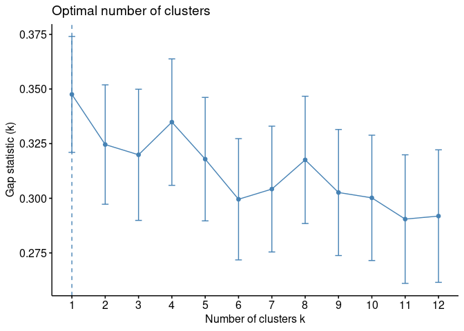

```r
res <- choix_dim_et_res(res.mbpls=recup_compos_X,
                        donnees=data.clean,
                        n_dim=3,
                        centers=6)
res$plot.opti_cluster
```

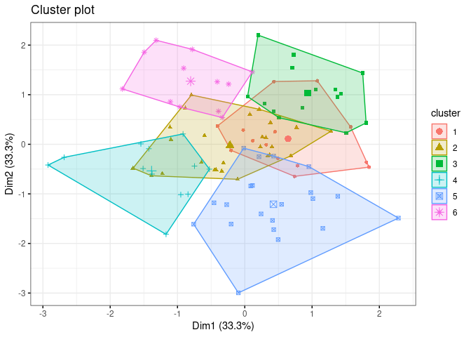

```r
res$analyse$plot.km
```

```r
res$analyse$res.table
```

|  | 1 | 2 | 3 | 4 | 5 | 6 | Overall |
| --- | --- | --- | --- | --- | --- | --- | --- |
|  | (N=14) | (N=26) | (N=15) | (N=12) | (N=21) | (N=12) | (N=100) |
| X09x3_FAB_CROISS_reg_rec |  |  |  |  |  |  |  |
| 0 | 9 (64.3%) | 12 (46.2%) | 3 (20.0%) | 10 (83.3%) | 11 (52.4%) | 10 (83.3%) | 55 (55.0%) |
| 1 | 5 (35.7%) | 14 (53.8%) | 12 (80.0%) | 2 (16.7%) | 10 (47.6%) | 2 (16.7%) | 45 (45.0%) |
| X22x1_LOC_INF_rec |  |  |  |  |  |  |  |
| 0 | 6 (42.9%) | 17 (65.4%) | 5 (33.3%) | 9 (75.0%) | 15 (71.4%) | 4 (33.3%) | 56 (56.0%) |
| 1 | 8 (57.1%) | 9 (34.6%) | 10 (66.7%) | 3 (25.0%) | 6 (28.6%) | 8 (66.7%) | 44 (44.0%) |
| X06x1_gene_majo_1_rec |  |  |  |  |  |  |  |
| 0 | 0 (0%) | 8 (30.8%) | 0 (0%) | 2 (16.7%) | 8 (38.1%) | 1 (8.3%) | 19 (19.0%) |
| 1 | 14 (100%) | 18 (69.2%) | 15 (100%) | 10 (83.3%) | 13 (61.9%) | 11 (91.7%) | 81 (81.0%) |
| X12x2_MAT_PC |  |  |  |  |  |  |  |
| 1 | 7 (50.0%) | 8 (30.8%) | 2 (13.3%) | 6 (50.0%) | 9 (42.9%) | 5 (41.7%) | 37 (37.0%) |
| 2 | 7 (50.0%) | 18 (69.2%) | 13 (86.7%) | 6 (50.0%) | 12 (57.1%) | 7 (58.3%) | 63 (63.0%) |
| T10_PS_EauDebi_3 |  |  |  |  |  |  |  |
| 0 | 2 (14.3%) | 16 (61.5%) | 6 (40.0%) | 5 (41.7%) | 10 (47.6%) | 3 (25.0%) | 42 (42.0%) |
| 1 | 10 (71.4%) | 5 (19.2%) | 8 (53.3%) | 6 (50.0%) | 4 (19.0%) | 9 (75.0%) | 42 (42.0%) |
| 2 | 2 (14.3%) | 5 (19.2%) | 1 (6.7%) | 1 (8.3%) | 7 (33.3%) | 0 (0%) | 16 (16.0%) |
| X12x2_MAT1FRLAV_1 |  |  |  |  |  |  |  |
| 0 | 4 (28.6%) | 0 (0%) | 6 (40.0%) | 3 (25.0%) | 5 (23.8%) | 7 (58.3%) | 25 (25.0%) |
| 1 | 5 (35.7%) | 9 (34.6%) | 1 (6.7%) | 9 (75.0%) | 7 (33.3%) | 4 (33.3%) | 35 (35.0%) |
| 2 | 5 (35.7%) | 17 (65.4%) | 8 (53.3%) | 0 (0%) | 9 (42.9%) | 1 (8.3%) | 40 (40.0%) |
| X07x1_AN_CONST4_mean_3 |  |  |  |  |  |  |  |
| 0 | 8 (57.1%) | 7 (26.9%) | 2 (13.3%) | 5 (41.7%) | 4 (19.0%) | 10 (83.3%) | 36 (36.0%) |
| 1 | 0 (0%) | 11 (42.3%) | 4 (26.7%) | 2 (16.7%) | 8 (38.1%) | 0 (0%) | 25 (25.0%) |
| 2 | 6 (42.9%) | 8 (30.8%) | 9 (60.0%) | 5 (41.7%) | 9 (42.9%) | 2 (16.7%) | 39 (39.0%) |
| T16_BS_TenueSpeciElev |  |  |  |  |  |  |  |
| 0 | 2 (14.3%) | 8 (30.8%) | 2 (13.3%) | 0 (0%) | 6 (28.6%) | 1 (8.3%) | 19 (19.0%) |
| 1 | 12 (85.7%) | 18 (69.2%) | 13 (86.7%) | 12 (100%) | 15 (71.4%) | 11 (91.7%) | 81 (81.0%) |
| X13x2_QUAI_t |  |  |  |  |  |  |  |
| 0 | 10 (71.4%) | 17 (65.4%) | 9 (60.0%) | 2 (16.7%) | 10 (47.6%) | 4 (33.3%) | 52 (52.0%) |
| 1 | 4 (28.6%) | 9 (34.6%) | 6 (40.0%) | 10 (83.3%) | 11 (52.4%) | 8 (66.7%) | 48 (48.0%) |
| ENG_TROU |  |  |  |  |  |  |  |
| 0 | 12 (85.7%) | 9 (34.6%) | 13 (86.7%) | 9 (75.0%) | 16 (76.2%) | 12 (100%) | 71 (71.0%) |
| 1 | 2 (14.3%) | 17 (65.4%) | 2 (13.3%) | 3 (25.0%) | 5 (23.8%) | 0 (0%) | 29 (29.0%) |
| X25x1_ElvAlterChoiPers |  |  |  |  |  |  |  |
| 0 | 10 (71.4%) | 9 (34.6%) | 10 (66.7%) | 5 (41.7%) | 9 (42.9%) | 4 (33.3%) | 47 (47.0%) |
| 1 | 4 (28.6%) | 17 (65.4%) | 5 (33.3%) | 7 (58.3%) | 12 (57.1%) | 8 (66.7%) | 53 (53.0%) |
| LR_LRF |  |  |  |  |  |  |  |
| 0 | 13 (92.9%) | 17 (65.4%) | 13 (86.7%) | 11 (91.7%) | 19 (90.5%) | 11 (91.7%) | 84 (84.0%) |
| 1 | 1 (7.1%) | 9 (34.6%) | 2 (13.3%) | 1 (8.3%) | 2 (9.5%) | 1 (8.3%) | 16 (16.0%) |
| T13_ENG_milieuDegrad.x |  |  |  |  |  |  |  |
| 0 | 12 (85.7%) | 8 (30.8%) | 10 (66.7%) | 4 (33.3%) | 11 (52.4%) | 6 (50.0%) | 51 (51.0%) |
| 1 | 2 (14.3%) | 18 (69.2%) | 5 (33.3%) | 8 (66.7%) | 10 (47.6%) | 6 (50.0%) | 49 (49.0%) |
| X18x2_ABBTX_PS |  |  |  |  |  |  |  |
| 0 | 14 (100%) | 1 (3.8%) | 3 (20.0%) | 12 (100%) | 21 (100%) | 5 (41.7%) | 56 (56.0%) |
| 1 | 0 (0%) | 25 (96.2%) | 12 (80.0%) | 0 (0%) | 0 (0%) | 7 (58.3%) | 44 (44.0%) |
| X19x2_ABB_E |  |  |  |  |  |  |  |
| 0 | 13 (92.9%) | 1 (3.8%) | 6 (40.0%) | 6 (50.0%) | 17 (81.0%) | 0 (0%) | 43 (43.0%) |
| 1 | 1 (7.1%) | 25 (96.2%) | 9 (60.0%) | 6 (50.0%) | 4 (19.0%) | 12 (100%) | 57 (57.0%) |
| A03_Pos10sVERS |  |  |  |  |  |  |  |
| 0 | 7 (50.0%) | 20 (76.9%) | 7 (46.7%) | 12 (100%) | 9 (42.9%) | 10 (83.3%) | 65 (65.0%) |
| 1 | 7 (50.0%) | 6 (23.1%) | 8 (53.3%) | 0 (0%) | 12 (57.1%) | 2 (16.7%) | 35 (35.0%) |
| A03_PosSeroMyAs |  |  |  |  |  |  |  |
| Non | 8 (57.1%) | 11 (42.3%) | 7 (46.7%) | 10 (83.3%) | 7 (33.3%) | 8 (66.7%) | 51 (51.0%) |
| Oui | 6 (42.9%) | 15 (57.7%) | 8 (53.3%) | 2 (16.7%) | 14 (66.7%) | 4 (33.3%) | 49 (49.0%) |
| T10_PS_AlimPoNourrLongpPo |  |  |  |  |  |  |  |
| Mean (SD) | 6.59 (2.70) | 5.32 (1.55) | 5.46 (2.52) | 11.5 (6.62) | 6.35 (2.89) | 8.04 (2.40) | 6.81 (3.67) |
| Median [Min, Max] | 7.01 [1.19, 11.8] | 5.45 [2.17, 8.10] | 5.15 [1.63, 10.2] | 8.38 [6.19, 25.9] | 6.92 [1.20, 12.8] | 7.84 [5.00, 12.5] | 6.57 [1.19, 25.9] |
| A03_TxPosSero22sTgReel |  |  |  |  |  |  |  |
| Mean (SD) | 9.93 (19.8) | 6.58 (15.1) | 12.9 (29.1) | 1.24 (4.04) | 1.41 (4.21) | 9.31 (16.9) | 6.59 (16.8) |
| Median [Min, Max] | 0 [0, 55.0] | 0.396 [0, 55.0] | 0 [0, 82.4] | 0 [0, 14.1] | 0 [0, 14.1] | 0.198 [0, 55.0] | 0 [0, 82.4] |
| A04_My10Mfloc |  |  |  |  |  |  |  |
| Mean (SD) | 26100 (78800) | 13600 (34000) | 6890 (14300) | 120000 (245000) | 23900 (61600) | 73100 (174000) | 36400 (115000) |
| Median [Min, Max] | 0 [0, 298000] | 0 [0, 139000] | 0 [0, 43800] | 24400 [0, 854000] | 0 [0, 271000] | 0 [0, 573000] | 0 [0, 854000] |
| A05_TxPos10sGRIPPEReel |  |  |  |  |  |  |  |
| Mean (SD) | 14.3 (25.1) | 41.0 (44.2) | 18.6 (32.2) | 25.9 (39.7) | 31.6 (41.5) | 9.21 (28.8) | 26.3 (38.3) |
| Median [Min, Max] | 0 [0, 73.9] | 21.1 [0, 100] | 0 [0, 100] | 0 [0, 100] | 10.6 [0, 100] | 0 [0, 100] | 0 [0, 100] |
| y |  |  |  |  |  |  |  |
| ENG_malade | 1 (7.1%) | 22 (84.6%) | 3 (20.0%) | 1 (8.3%) | 12 (57.1%) | 1 (8.3%) | 40 (40.0%) |
| PS_malade | 9 (64.3%) | 1 (3.8%) | 12 (80.0%) | 0 (0%) | 6 (28.6%) | 3 (25.0%) | 31 (31.0%) |
| Sain | 4 (28.6%) | 3 (11.5%) | 0 (0%) | 11 (91.7%) | 3 (14.3%) | 8 (66.7%) | 29 (29.0%) |

```r
res$analyse$res.catdes
```

```
## $`1`
##                            Cla/Mod    Mod/Cla Global      p.value    v.test
## X19x2_ABB_E=0            30.232558  92.857143     43 5.073078e-05  4.052234
## X18x2_ABBTX_PS=0         25.000000 100.000000     56 1.313676e-04  3.823881
## T13_ENG_milieuDegrad.x=0 23.529412  85.714286     51 5.339878e-03  2.785782
## y=PS_malade              29.032258  64.285714     31 7.079422e-03  2.693085
## T10_PS_EauDebi_3=1       23.809524  71.428571     42 2.100338e-02  2.307924
## X06x1_gene_majo_1_rec=1  17.283951 100.000000     81 4.126306e-02  2.040877
## X06x1_gene_majo_1_rec=0   0.000000   0.000000     19 4.126306e-02 -2.040877
## T10_PS_EauDebi_3=0        4.761905  14.285714     42 2.383487e-02 -2.259781
## X07x1_AN_CONST4_mean_3=1  0.000000   0.000000     25 1.268834e-02 -2.492399
## y=ENG_malade              2.500000   7.142857     40 5.462390e-03 -2.778420
## T13_ENG_milieuDegrad.x=1  4.081633  14.285714     49 5.339878e-03 -2.785782
## X18x2_ABBTX_PS=1          0.000000   0.000000     44 1.313676e-04 -3.823881
## X19x2_ABB_E=1             1.754386   7.142857     57 5.073078e-05 -4.052234
##
## $`2`
##                            Cla/Mod   Mod/Cla Global      p.value    v.test
## X18x2_ABBTX_PS=1         56.818182 96.153846     44 1.157183e-10  6.444845
## y=ENG_malade             55.000000 84.615385     40 8.803690e-08  5.349830
## X19x2_ABB_E=1            43.859649 96.153846     57 6.452621e-07  4.977153
## ENG_TROU=1               58.620690 65.384615     29 6.657359e-06  4.504359
## X12x2_MAT1FRLAV_1=2      42.500000 65.384615     40 2.871308e-03  2.981190
## LR_LRF=1                 56.250000 34.615385     16 5.842674e-03  2.756482
## T13_ENG_milieuDegrad.x=1 36.734694 69.230769     49 1.851390e-02  2.355177
## T10_PS_EauDebi_3=0       38.095238 61.538462     42 2.256185e-02  2.280773
## X07x1_AN_CONST4_mean_3=1 44.000000 42.307692     25 2.512873e-02  2.239418
## y=Sain                   10.344828 11.538462     29 2.087032e-02 -2.310322
## T13_ENG_milieuDegrad.x=0 15.686275 30.769231     51 1.851390e-02 -2.355177
## T10_PS_EauDebi_3=1       11.904762 19.230769     42 6.186047e-03 -2.737753
## LR_LRF=0                 20.238095 65.384615     84 5.842674e-03 -2.756482
## y=PS_malade               3.225806  3.846154     31 2.039821e-04 -3.714033
## X12x2_MAT1FRLAV_1=0       0.000000  0.000000     25 1.445618e-04 -3.800230
## ENG_TROU=0               12.676056 34.615385     71 6.657359e-06 -4.504359
## X19x2_ABB_E=0             2.325581  3.846154     43 6.452621e-07 -4.977153
## X18x2_ABBTX_PS=0          1.785714  3.846154     56 1.157183e-10 -6.444845
##
## $`3`
##                              Cla/Mod    Mod/Cla Global      p.value    v.test
## y=PS_malade                38.709677  80.000000     31 0.0000331525  4.150655
```

[output cut: 43 more lines]

```
## $`6`
##                              Cla/Mod    Mod/Cla Global      p.value    v.test
## X07x1_AN_CONST4_mean_3=0   27.777778  83.333333     36 0.0005634380  3.448630
## X19x2_ABB_E=1              21.052632 100.000000     57 0.0006733353  3.400212
## y=Sain                     27.586207  66.666667     29 0.0051596255  2.796895
## X12x2_MAT1FRLAV_1=0        28.000000  58.333333     25 0.0106819202  2.552936
## ENG_TROU=0                 16.901408 100.000000     71 0.0121881953  2.506648
## T10_PS_EauDebi_3=1         21.428571  75.000000     42 0.0182228731  2.361058
## X09x3_FAB_CROISS_reg_rec=0 18.181818  83.333333     55 0.0386534936  2.067857
## X09x3_FAB_CROISS_reg_rec=1  4.444444  16.666667     45 0.0386534936 -2.067857
## X07x1_AN_CONST4_mean_3=1    0.000000   0.000000     25 0.0248699218 -2.243417
## y=ENG_malade                2.500000   8.333333     40 0.0157143868 -2.415482
## X12x2_MAT1FRLAV_1=2         2.500000   8.333333     40 0.0157143868 -2.415482
## ENG_TROU=1                  0.000000   0.000000     29 0.0121881953 -2.506648
## X19x2_ABB_E=0               0.000000   0.000000     43 0.0006733353 -3.400212
```

# Réaliser une classification k-means à partir des 4 premières dimensions

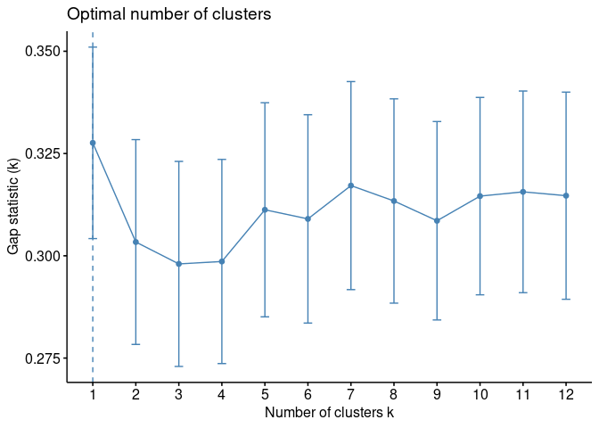

```r
res <- choix_dim_et_res(res.mbpls=recup_compos_X,
                        donnees=data.clean,
                        n_dim=4,
                        centers=3)
res$plot.opti_cluster
```

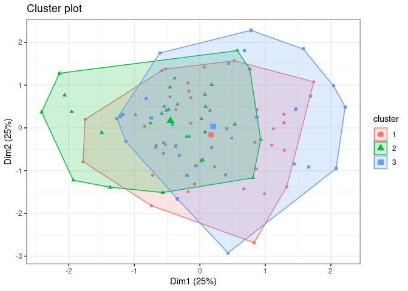

```r
res$analyse$plot.km
```

```r
res$analyse$res.table
```

|  | 1 | 2 | 3 | Overall |
| --- | --- | --- | --- | --- |
|  | (N=37) | (N=29) | (N=34) | (N=100) |
| X09x3_FAB_CROISS_reg_rec |  |  |  |  |
| 0 | 21 (56.8%) | 10 (34.5%) | 24 (70.6%) | 55 (55.0%) |
| 1 | 16 (43.2%) | 19 (65.5%) | 10 (29.4%) | 45 (45.0%) |
| X22x1_LOC_INF_rec |  |  |  |  |
| 0 | 15 (40.5%) | 20 (69.0%) | 21 (61.8%) | 56 (56.0%) |
| 1 | 22 (59.5%) | 9 (31.0%) | 13 (38.2%) | 44 (44.0%) |
| X06x1_gene_majo_1_rec |  |  |  |  |
| 0 | 1 (2.7%) | 13 (44.8%) | 5 (14.7%) | 19 (19.0%) |
| 1 | 36 (97.3%) | 16 (55.2%) | 29 (85.3%) | 81 (81.0%) |
| X12x2_MAT_PC |  |  |  |  |
| 1 | 13 (35.1%) | 12 (41.4%) | 12 (35.3%) | 37 (37.0%) |
| 2 | 24 (64.9%) | 17 (58.6%) | 22 (64.7%) | 63 (63.0%) |
| T10_PS_EauDebi_3 |  |  |  |  |
| 0 | 6 (16.2%) | 14 (48.3%) | 22 (64.7%) | 42 (42.0%) |
| 1 | 30 (81.1%) | 9 (31.0%) | 3 (8.8%) | 42 (42.0%) |
| 2 | 1 (2.7%) | 6 (20.7%) | 9 (26.5%) | 16 (16.0%) |
| X12x2_MAT1FRLAV_1 |  |  |  |  |
| 0 | 17 (45.9%) | 5 (17.2%) | 3 (8.8%) | 25 (25.0%) |
| 1 | 13 (35.1%) | 14 (48.3%) | 8 (23.5%) | 35 (35.0%) |
| 2 | 7 (18.9%) | 10 (34.5%) | 23 (67.6%) | 40 (40.0%) |
| X07x1_AN_CONST4_mean_3 |  |  |  |  |
| 0 | 19 (51.4%) | 10 (34.5%) | 7 (20.6%) | 36 (36.0%) |
| 1 | 4 (10.8%) | 14 (48.3%) | 7 (20.6%) | 25 (25.0%) |
| 2 | 14 (37.8%) | 5 (17.2%) | 20 (58.8%) | 39 (39.0%) |
| T16_BS_TenueSpeciElev |  |  |  |  |
| 0 | 4 (10.8%) | 9 (31.0%) | 6 (17.6%) | 19 (19.0%) |
| 1 | 33 (89.2%) | 20 (69.0%) | 28 (82.4%) | 81 (81.0%) |
| X13x2_QUAI_t |  |  |  |  |
| 0 | 17 (45.9%) | 14 (48.3%) | 21 (61.8%) | 52 (52.0%) |
| 1 | 20 (54.1%) | 15 (51.7%) | 13 (38.2%) | 48 (48.0%) |
| ENG_TROU |  |  |  |  |
| 0 | 32 (86.5%) | 25 (86.2%) | 14 (41.2%) | 71 (71.0%) |
| 1 | 5 (13.5%) | 4 (13.8%) | 20 (58.8%) | 29 (29.0%) |
| X25x1_ElvAlterChoiPers |  |  |  |  |
| 0 | 20 (54.1%) | 6 (20.7%) | 21 (61.8%) | 47 (47.0%) |
| 1 | 17 (45.9%) | 23 (79.3%) | 13 (38.2%) | 53 (53.0%) |
| LR_LRF |  |  |  |  |
| 0 | 33 (89.2%) | 28 (96.6%) | 23 (67.6%) | 84 (84.0%) |
| 1 | 4 (10.8%) | 1 (3.4%) | 11 (32.4%) | 16 (16.0%) |
| T13_ENG_milieuDegrad.x |  |  |  |  |
| 0 | 23 (62.2%) | 14 (48.3%) | 14 (41.2%) | 51 (51.0%) |
| 1 | 14 (37.8%) | 15 (51.7%) | 20 (58.8%) | 49 (49.0%) |
| X18x2_ABBTX_PS |  |  |  |  |
| 0 | 21 (56.8%) | 22 (75.9%) | 13 (38.2%) | 56 (56.0%) |
| 1 | 16 (43.2%) | 7 (24.1%) | 21 (61.8%) | 44 (44.0%) |
| X19x2_ABB_E |  |  |  |  |
| 0 | 13 (35.1%) | 19 (65.5%) | 11 (32.4%) | 43 (43.0%) |
| 1 | 24 (64.9%) | 10 (34.5%) | 23 (67.6%) | 57 (57.0%) |
| A03_Pos10sVERS |  |  |  |  |
| 0 | 28 (75.7%) | 18 (62.1%) | 19 (55.9%) | 65 (65.0%) |
| 1 | 9 (24.3%) | 11 (37.9%) | 15 (44.1%) | 35 (35.0%) |
| A03_PosSeroMyAs |  |  |  |  |
| Non | 23 (62.2%) | 12 (41.4%) | 16 (47.1%) | 51 (51.0%) |
| Oui | 14 (37.8%) | 17 (58.6%) | 18 (52.9%) | 49 (49.0%) |
| T10_PS_AlimPoNourrLongpPo |  |  |  |  |
| Mean (SD) | 8.12 (4.69) | 6.68 (2.60) | 5.49 (2.62) | 6.81 (3.67) |
| Median [Min, Max] | 7.27 [1.19, 25.9] | 6.51 [1.20, 12.8] | 5.37 [1.88, 14.8] | 6.57 [1.19, 25.9] |
| A03_TxPosSero22sTgReel |  |  |  |  |
| Mean (SD) | 6.06 (14.0) | 1.51 (7.67) | 11.5 (23.2) | 6.59 (16.8) |
| Median [Min, Max] | 0 [0, 55.0] | 0 [0, 41.4] | 0.396 [0, 82.4] | 0 [0, 82.4] |
| A04_My10Mfloc |  |  |  |  |
| Mean (SD) | 38100 (111000) | 30600 (72200) | 39500 (148000) | 36400 (115000) |
| Median [Min, Max] | 0 [0, 573000] | 0 [0, 290000] | 0 [0, 854000] | 0 [0, 854000] |
| A05_TxPos10sGRIPPEReel |  |  |  |  |
| Mean (SD) | 13.4 (29.0) | 30.9 (42.9) | 36.5 (40.0) | 26.3 (38.3) |
| Median [Min, Max] | 0 [0, 100] | 0 [0, 100] | 21.1 [0, 100] | 0 [0, 100] |
| y |  |  |  |  |
| ENG_malade | 4 (10.8%) | 19 (65.5%) | 17 (50.0%) | 40 (40.0%) |
| PS_malade | 17 (45.9%) | 7 (24.1%) | 7 (20.6%) | 31 (31.0%) |
| Sain | 16 (43.2%) | 3 (10.3%) | 10 (29.4%) | 29 (29.0%) |

```r
res$analyse$res.catdes
```

```
## $`1`
##                            Cla/Mod   Mod/Cla Global      p.value    v.test
## T10_PS_EauDebi_3=1       71.428571 81.081081     42 1.077556e-09  6.097477
## X12x2_MAT1FRLAV_1=0      68.000000 45.945946     25 3.455254e-04  3.578535
## X06x1_gene_majo_1_rec=1  44.444444 97.297297     81 8.164082e-04  3.347171
## ENG_TROU=0               45.070423 86.486486     71 8.606731e-03  2.627293
## y=PS_malade              54.838710 45.945946     31 1.631910e-02  2.401700
## X07x1_AN_CONST4_mean_3=0 52.777778 51.351351     36 1.696937e-02  2.387371
## X22x1_LOC_INF_rec=1      50.000000 59.459459     44 1.934372e-02  2.338840
## y=Sain                   55.172414 43.243243     29 1.988746e-02  2.328464
## X22x1_LOC_INF_rec=0      26.785714 40.540541     56 1.934372e-02 -2.338840
## X07x1_AN_CONST4_mean_3=1 16.000000 10.810811     25 1.146630e-02 -2.528157
## ENG_TROU=1               17.241379 13.513514     29 8.606731e-03 -2.627293
## T10_PS_EauDebi_3=2        6.250000  2.702703     16 3.902086e-03 -2.885971
## X12x2_MAT1FRLAV_1=2      17.500000 18.918919     40 9.466358e-04 -3.305925
## X06x1_gene_majo_1_rec=0   5.263158  2.702703     19 8.164082e-04 -3.347171
## T10_PS_EauDebi_3=0       14.285714 16.216216     42 5.251886e-05 -4.044125
## y=ENG_malade             10.000000 10.810811     40 2.779984e-06 -4.686440
##
## $`2`
##                             Cla/Mod   Mod/Cla Global      p.value    v.test
## X06x1_gene_majo_1_rec=0    68.42105 44.827586     19 8.990188e-05  3.916344
## X25x1_ElvAlterChoiPers=1   43.39623 79.310345     53 7.606838e-04  3.366718
## X07x1_AN_CONST4_mean_3=1   56.00000 48.275862     25 1.160844e-03  3.248330
## y=ENG_malade               47.50000 65.517241     40 1.187873e-03  3.241776
## X19x2_ABB_E=0              44.18605 65.517241     43 4.508981e-03  2.840168
## X09x3_FAB_CROISS_reg_rec=1 42.22222 65.517241     45 9.891089e-03  2.579614
## X18x2_ABBTX_PS=0           39.28571 75.862069     56 1.111806e-02  2.538966
## LR_LRF=0                   33.33333 96.551724     84 2.446794e-02  2.249701
## ENG_TROU=0                 35.21127 86.206897     71 3.159897e-02  2.149447
## ENG_TROU=1                 13.79310 13.793103     29 3.159897e-02 -2.149447
## LR_LRF=1                    6.25000  3.448276     16 2.446794e-02 -2.249701
## X18x2_ABBTX_PS=1           15.90909 24.137931     44 1.111806e-02 -2.538966
## X09x3_FAB_CROISS_reg_rec=0 18.18182 34.482759     55 9.891089e-03 -2.579614
## y=Sain                     10.34483 10.344828     29 7.339558e-03 -2.681032
## X19x2_ABB_E=1              17.54386 34.482759     57 4.508981e-03 -2.840168
## X07x1_AN_CONST4_mean_3=2   12.82051 17.241379     39 4.122864e-03 -2.868605
## X25x1_ElvAlterChoiPers=0   12.76596 20.689655     47 7.606838e-04 -3.366718
## X06x1_gene_majo_1_rec=1    19.75309 55.172414     81 8.990188e-05 -3.916344
##
## $`3`
##                              Cla/Mod   Mod/Cla Global      p.value    v.test
## ENG_TROU=1                 68.965517 58.823529     29 5.083550e-06  4.561310
## X12x2_MAT1FRLAV_1=2        57.500000 67.647059     40 7.095343e-05  3.973066
## T10_PS_EauDebi_3=0         52.380952 64.705882     42 1.213479e-03  3.235693
## LR_LRF=1                   68.750000 32.352941     16 2.554800e-03  3.016774
## X07x1_AN_CONST4_mean_3=2   51.282051 58.823529     39 4.451368e-03  2.844267
## X18x2_ABBTX_PS=1           47.727273 61.764706     44 1.188677e-02  2.515488
## X09x3_FAB_CROISS_reg_rec=0 43.636364 70.588235     55 2.645398e-02  2.219482
## X25x1_ElvAlterChoiPers=0   44.680851 61.764706     47 3.740157e-02  2.081353
## X25x1_ElvAlterChoiPers=1   24.528302 38.235294     53 3.740157e-02 -2.081353
## X09x3_FAB_CROISS_reg_rec=1 22.222222 29.411765     45 2.645398e-02 -2.219482
## X07x1_AN_CONST4_mean_3=0   19.444444 20.588235     36 2.185498e-02 -2.292879
## X18x2_ABBTX_PS=0           23.214286 38.235294     56 1.188677e-02 -2.515488
## X12x2_MAT1FRLAV_1=0        12.000000  8.823529     25 6.291411e-03 -2.732194
## LR_LRF=0                   27.380952 67.647059     84 2.554800e-03 -3.016774
## ENG_TROU=0                 19.718310 41.176471     71 5.083550e-06 -4.561310
## T10_PS_EauDebi_3=1          7.142857  8.823529     42 5.872231e-07 -4.995372
```

# Réaliser une classification k-means à partir des 5 premières dimensions

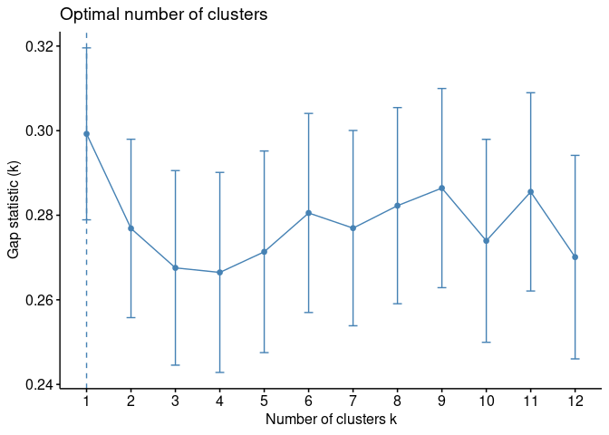

```r
res <- choix_dim_et_res(res.mbpls=recup_compos_X,
                        donnees=data.clean,
                        n_dim=5,
                        centers=3)
res$plot.opti_cluster
```

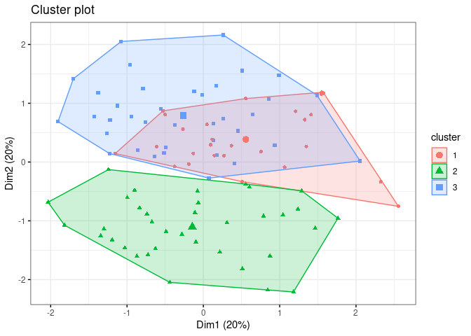

```r
res$analyse$plot.km
```

```r
res$analyse$res.table
```

|  | 1 | 2 | 3 | Overall |
| --- | --- | --- | --- | --- |
|  | (N=27) | (N=36) | (N=37) | (N=100) |
| X09x3_FAB_CROISS_reg_rec |  |  |  |  |
| 0 | 17 (63.0%) | 16 (44.4%) | 22 (59.5%) | 55 (55.0%) |
| 1 | 10 (37.0%) | 20 (55.6%) | 15 (40.5%) | 45 (45.0%) |
| X22x1_LOC_INF_rec |  |  |  |  |
| 0 | 19 (70.4%) | 19 (52.8%) | 18 (48.6%) | 56 (56.0%) |
| 1 | 8 (29.6%) | 17 (47.2%) | 19 (51.4%) | 44 (44.0%) |
| X06x1_gene_majo_1_rec |  |  |  |  |
| 0 | 9 (33.3%) | 9 (25.0%) | 1 (2.7%) | 19 (19.0%) |
| 1 | 18 (66.7%) | 27 (75.0%) | 36 (97.3%) | 81 (81.0%) |
| X12x2_MAT_PC |  |  |  |  |
| 1 | 13 (48.1%) | 11 (30.6%) | 13 (35.1%) | 37 (37.0%) |
| 2 | 14 (51.9%) | 25 (69.4%) | 24 (64.9%) | 63 (63.0%) |
| T10_PS_EauDebi_3 |  |  |  |  |
| 0 | 12 (44.4%) | 21 (58.3%) | 9 (24.3%) | 42 (42.0%) |
| 1 | 6 (22.2%) | 9 (25.0%) | 27 (73.0%) | 42 (42.0%) |
| 2 | 9 (33.3%) | 6 (16.7%) | 1 (2.7%) | 16 (16.0%) |
| X12x2_MAT1FRLAV_1 |  |  |  |  |
| 0 | 5 (18.5%) | 3 (8.3%) | 17 (45.9%) | 25 (25.0%) |
| 1 | 9 (33.3%) | 11 (30.6%) | 15 (40.5%) | 35 (35.0%) |
| 2 | 13 (48.1%) | 22 (61.1%) | 5 (13.5%) | 40 (40.0%) |
| X07x1_AN_CONST4_mean_3 |  |  |  |  |
| 0 | 6 (22.2%) | 9 (25.0%) | 21 (56.8%) | 36 (36.0%) |
| 1 | 7 (25.9%) | 15 (41.7%) | 3 (8.1%) | 25 (25.0%) |
| 2 | 14 (51.9%) | 12 (33.3%) | 13 (35.1%) | 39 (39.0%) |
| T16_BS_TenueSpeciElev |  |  |  |  |
| 0 | 6 (22.2%) | 10 (27.8%) | 3 (8.1%) | 19 (19.0%) |
| 1 | 21 (77.8%) | 26 (72.2%) | 34 (91.9%) | 81 (81.0%) |
| X13x2_QUAI_t |  |  |  |  |
| 0 | 16 (59.3%) | 25 (69.4%) | 11 (29.7%) | 52 (52.0%) |
| 1 | 11 (40.7%) | 11 (30.6%) | 26 (70.3%) | 48 (48.0%) |
| ENG_TROU |  |  |  |  |
| 0 | 21 (77.8%) | 17 (47.2%) | 33 (89.2%) | 71 (71.0%) |
| 1 | 6 (22.2%) | 19 (52.8%) | 4 (10.8%) | 29 (29.0%) |
| X25x1_ElvAlterChoiPers |  |  |  |  |
| 0 | 12 (44.4%) | 15 (41.7%) | 20 (54.1%) | 47 (47.0%) |
| 1 | 15 (55.6%) | 21 (58.3%) | 17 (45.9%) | 53 (53.0%) |
| LR_LRF |  |  |  |  |
| 0 | 26 (96.3%) | 25 (69.4%) | 33 (89.2%) | 84 (84.0%) |
| 1 | 1 (3.7%) | 11 (30.6%) | 4 (10.8%) | 16 (16.0%) |
| T13_ENG_milieuDegrad.x |  |  |  |  |
| 0 | 17 (63.0%) | 13 (36.1%) | 21 (56.8%) | 51 (51.0%) |
| 1 | 10 (37.0%) | 23 (63.9%) | 16 (43.2%) | 49 (49.0%) |
| X18x2_ABBTX_PS |  |  |  |  |
| 0 | 26 (96.3%) | 2 (5.6%) | 28 (75.7%) | 56 (56.0%) |
| 1 | 1 (3.7%) | 34 (94.4%) | 9 (24.3%) | 44 (44.0%) |
| X19x2_ABB_E |  |  |  |  |
| 0 | 26 (96.3%) | 3 (8.3%) | 14 (37.8%) | 43 (43.0%) |
| 1 | 1 (3.7%) | 33 (91.7%) | 23 (62.2%) | 57 (57.0%) |
| A03_Pos10sVERS |  |  |  |  |
| 0 | 13 (48.1%) | 24 (66.7%) | 28 (75.7%) | 65 (65.0%) |
| 1 | 14 (51.9%) | 12 (33.3%) | 9 (24.3%) | 35 (35.0%) |
| A03_PosSeroMyAs |  |  |  |  |
| Non | 12 (44.4%) | 17 (47.2%) | 22 (59.5%) | 51 (51.0%) |
| Oui | 15 (55.6%) | 19 (52.8%) | 15 (40.5%) | 49 (49.0%) |
| T10_PS_AlimPoNourrLongpPo |  |  |  |  |
| Mean (SD) | 6.77 (3.35) | 5.40 (1.73) | 8.20 (4.69) | 6.81 (3.67) |
| Median [Min, Max] | 6.92 [1.20, 14.8] | 5.45 [2.09, 8.75] | 7.47 [1.19, 25.9] | 6.57 [1.19, 25.9] |
| A03_TxPosSero22sTgReel |  |  |  |  |
| Mean (SD) | 6.71 (18.8) | 7.82 (18.7) | 5.31 (13.5) | 6.59 (16.8) |
| Median [Min, Max] | 0 [0, 82.4] | 0 [0, 82.4] | 0 [0, 55.0] | 0 [0, 82.4] |
| A04_My10Mfloc |  |  |  |  |
| Mean (SD) | 27800 (74100) | 11600 (29700) | 66900 (173000) | 36400 (115000) |
| Median [Min, Max] | 0 [0, 290000] | 0 [0, 139000] | 0 [0, 854000] | 0 [0, 854000] |
| A05_TxPos10sGRIPPEReel |  |  |  |  |
| Mean (SD) | 32.4 (40.1) | 36.5 (42.7) | 12.0 (27.4) | 26.3 (38.3) |
| Median [Min, Max] | 10.6 [0, 100] | 5.28 [0, 100] | 0 [0, 100] | 0 [0, 100] |
| y |  |  |  |  |
| ENG_malade | 10 (37.0%) | 25 (69.4%) | 5 (13.5%) | 40 (40.0%) |
| PS_malade | 10 (37.0%) | 7 (19.4%) | 14 (37.8%) | 31 (31.0%) |
| Sain | 7 (25.9%) | 4 (11.1%) | 18 (48.6%) | 29 (29.0%) |

```r
res$analyse$res.catdes
```

```
## $`1`
##                           Cla/Mod   Mod/Cla Global      p.value    v.test
## X19x2_ABB_E=0           60.465116 96.296296     43 1.279741e-11  6.770911
## X18x2_ABBTX_PS=0        46.428571 96.296296     56 1.602280e-07  5.240401
## T10_PS_EauDebi_3=2      56.250000 33.333333     16 8.129229e-03  2.646655
## LR_LRF=0                30.952381 96.296296     84 3.700906e-02  2.085664
## X06x1_gene_majo_1_rec=0 47.368421 33.333333     19 3.751428e-02  2.080123
## A03_Pos10sVERS=1        40.000000 51.851852     35 3.832828e-02  2.071327
## A03_Pos10sVERS=0        20.000000 48.148148     65 3.832828e-02 -2.071327
## X06x1_gene_majo_1_rec=1 22.222222 66.666667     81 3.751428e-02 -2.080123
## LR_LRF=1                 6.250000  3.703704     16 3.700906e-02 -2.085664
## T10_PS_EauDebi_3=1      14.285714 22.222222     42 1.533137e-02 -2.424455
## X18x2_ABBTX_PS=1         2.272727  3.703704     44 1.602280e-07 -5.240401
## X19x2_ABB_E=1            1.754386  3.703704     57 1.279741e-11 -6.770911
##
## $`2`
##                            Cla/Mod   Mod/Cla Global      p.value    v.test
## X18x2_ABBTX_PS=1         77.272727 94.444444     44 1.972932e-15  7.943035
## X19x2_ABB_E=1            57.894737 91.666667     57 5.195569e-08  5.444484
## y=ENG_malade             62.500000 69.444444     40 8.937264e-06  4.441407
## ENG_TROU=1               65.517241 52.777778     29 1.417460e-04  3.805102
## X12x2_MAT1FRLAV_1=2      55.000000 61.111111     40 1.563308e-03  3.162667
## LR_LRF=1                 68.750000 30.555556     16 4.740466e-03  2.824160
## X07x1_AN_CONST4_mean_3=1 60.000000 41.666667     25 5.503502e-03  2.775983
## X13x2_QUAI_t=0           48.076923 69.444444     52 9.741330e-03  2.584879
## T10_PS_EauDebi_3=0       50.000000 58.333333     42 1.518482e-02  2.427941
## T13_ENG_milieuDegrad.x=1 46.938776 63.888889     49 2.818402e-02  2.194715
## T13_ENG_milieuDegrad.x=0 25.490196 36.111111     51 2.818402e-02 -2.194715
## T10_PS_EauDebi_3=1       21.428571 25.000000     42 1.039047e-02 -2.562556
## X13x2_QUAI_t=1           22.916667 30.555556     48 9.741330e-03 -2.584879
## LR_LRF=0                 29.761905 69.444444     84 4.740466e-03 -2.824160
## X12x2_MAT1FRLAV_1=0      12.000000  8.333333     25 3.205513e-03 -2.947310
## y=Sain                   13.793103 11.111111     29 2.688254e-03 -3.001305
## ENG_TROU=0               23.943662 47.222222     71 1.417460e-04 -3.805102
## X19x2_ABB_E=0             6.976744  8.333333     43 5.195569e-08 -5.444484
## X18x2_ABBTX_PS=0          3.571429  5.555556     56 1.972932e-15 -7.943035
##
## $`3`
##                            Cla/Mod   Mod/Cla Global      p.value    v.test
## T10_PS_EauDebi_3=1       64.285714 72.972973     42 1.865282e-06  4.767498
## X12x2_MAT1FRLAV_1=0      68.000000 45.945946     25 3.455254e-04  3.578535
## X13x2_QUAI_t=1           54.166667 70.270270     48 7.318286e-04  3.377369
## X06x1_gene_majo_1_rec=1  44.444444 97.297297     81 8.164082e-04  3.347171
## X07x1_AN_CONST4_mean_3=0 58.333333 56.756757     36 1.225031e-03  3.232987
## y=Sain                   62.068966 48.648649     29 1.310452e-03  3.213681
## ENG_TROU=0               46.478873 89.189189     71 1.804133e-03  3.120714
## X18x2_ABBTX_PS=0         50.000000 75.675676     56 2.525875e-03  3.020224
## T16_BS_TenueSpeciElev=1  41.975309 91.891892     81 3.324730e-02  2.129084
## T16_BS_TenueSpeciElev=0  15.789474  8.108108     19 3.324730e-02 -2.129084
## T10_PS_EauDebi_3=0       21.428571 24.324324     42 6.416064e-03 -2.725724
## T10_PS_EauDebi_3=2        6.250000  2.702703     16 3.902086e-03 -2.885971
## X18x2_ABBTX_PS=1         20.454545 24.324324     44 2.525875e-03 -3.020224
## X07x1_AN_CONST4_mean_3=1 12.000000  8.108108     25 2.255397e-03 -3.054362
## ENG_TROU=1               13.793103 10.810811     29 1.804133e-03 -3.120714
## X06x1_gene_majo_1_rec=0   5.263158  2.702703     19 8.164082e-04 -3.347171
## X13x2_QUAI_t=0           21.153846 29.729730     52 7.318286e-04 -3.377369
## y=ENG_malade             12.500000 13.513514     40 2.508719e-05 -4.214014
## X12x2_MAT1FRLAV_1=2      12.500000 13.513514     40 2.508719e-05 -4.214014
```